# Risk Factor Analysis

## Outcome Variable

**Outcome Variable:** y_rate_haz

## Predictor Variables

**Intervention Variable:** fage

**Adjustment Set:**

- arm
- W_mage
- meducyrs
- feducyrs
- W_mhtcm
- W_mwtkg
- W_mbmi
- W_fhtcm
- single
- brthmon
- delta_W_mage
- delta_meducyrs
- delta_feducyrs
- delta_W_mhtcm
- delta_W_mwtkg
- delta_W_mbmi
- delta_W_fhtcm
- delta_single
- delta_brthmon

## Stratifying Variables

The analysis was stratified on these variable(s):

- agecat
- studyid
- country

## Data Summary

| agecat | studyid | country | fage | n_cell | n |
| --- | --- | --- | --- | --- | --- |
| 0-3 months | ki0047075b-MAL-ED | BANGLADESH | >=35 | 101 | 150 |
| 0-3 months | ki0047075b-MAL-ED | BANGLADESH | [25-30) | 14 | 150 |
| 0-3 months | ki0047075b-MAL-ED | BANGLADESH | [30-35) | 35 | 150 |
| 0-3 months | ki1119695-PROBIT | BELARUS | >=35 | 1242 | 12294 |
| 0-3 months | ki1119695-PROBIT | BELARUS | <25 | 4068 | 12294 |
| 0-3 months | ki1119695-PROBIT | BELARUS | [25-30) | 4633 | 12294 |
| 0-3 months | ki1119695-PROBIT | BELARUS | [30-35) | 2351 | 12294 |
| 0-3 months | ki0047075b-MAL-ED | BRAZIL | >=35 | 35 | 68 |
| 0-3 months | ki0047075b-MAL-ED | BRAZIL | <25 | 3 | 68 |
| 0-3 months | ki0047075b-MAL-ED | BRAZIL | [25-30) | 7 | 68 |
| 0-3 months | ki0047075b-MAL-ED | BRAZIL | [30-35) | 23 | 68 |
| 0-3 months | ki1135781-COHORTS | GUATEMALA | >=35 | 294 | 706 |
| 0-3 months | ki1135781-COHORTS | GUATEMALA | <25 | 108 | 706 |
| 0-3 months | ki1135781-COHORTS | GUATEMALA | [25-30) | 147 | 706 |
| 0-3 months | ki1135781-COHORTS | GUATEMALA | [30-35) | 157 | 706 |
| 0-3 months | ki0047075b-MAL-ED | INDIA | >=35 | 59 | 133 |
| 0-3 months | ki0047075b-MAL-ED | INDIA | <25 | 2 | 133 |
| 0-3 months | ki0047075b-MAL-ED | INDIA | [25-30) | 25 | 133 |
| 0-3 months | ki0047075b-MAL-ED | INDIA | [30-35) | 47 | 133 |
| 0-3 months | ki1000304b-SAS-CompFeed | INDIA | >=35 | 109 | 1165 |
| 0-3 months | ki1000304b-SAS-CompFeed | INDIA | <25 | 316 | 1165 |
| 0-3 months | ki1000304b-SAS-CompFeed | INDIA | [25-30) | 487 | 1165 |
| 0-3 months | ki1000304b-SAS-CompFeed | INDIA | [30-35) | 253 | 1165 |
| 0-3 months | ki0047075b-MAL-ED | NEPAL | >=35 | 32 | 63 |
| 0-3 months | ki0047075b-MAL-ED | NEPAL | [25-30) | 7 | 63 |
| 0-3 months | ki0047075b-MAL-ED | NEPAL | [30-35) | 24 | 63 |
| 0-3 months | ki0047075b-MAL-ED | PERU | >=35 | 43 | 80 |
| 0-3 months | ki0047075b-MAL-ED | PERU | <25 | 4 | 80 |
| 0-3 months | ki0047075b-MAL-ED | PERU | [25-30) | 17 | 80 |
| 0-3 months | ki0047075b-MAL-ED | PERU | [30-35) | 16 | 80 |

[output cut: 138 more lines]

The following strata were considered:

- agecat: 0-3 months, studyid: ki0047075b-MAL-ED, country: BANGLADESH
- agecat: 0-3 months, studyid: ki0047075b-MAL-ED, country: BRAZIL
- agecat: 0-3 months, studyid: ki0047075b-MAL-ED, country: INDIA
- agecat: 0-3 months, studyid: ki0047075b-MAL-ED, country: NEPAL
- agecat: 0-3 months, studyid: ki0047075b-MAL-ED, country: PERU
- agecat: 0-3 months, studyid: ki0047075b-MAL-ED, country: SOUTH AFRICA
- agecat: 0-3 months, studyid: ki0047075b-MAL-ED, country: TANZANIA, UNITED REPUBLIC OF
- agecat: 0-3 months, studyid: ki1000304b-SAS-CompFeed, country: INDIA
- agecat: 0-3 months, studyid: ki1119695-PROBIT, country: BELARUS
- agecat: 0-3 months, studyid: ki1135781-COHORTS, country: GUATEMALA
- agecat: 12-24 months, studyid: ki0047075b-MAL-ED, country: BANGLADESH
- agecat: 12-24 months, studyid: ki0047075b-MAL-ED, country: BRAZIL
- agecat: 12-24 months, studyid: ki0047075b-MAL-ED, country: INDIA
- agecat: 12-24 months, studyid: ki0047075b-MAL-ED, country: NEPAL
- agecat: 12-24 months, studyid: ki0047075b-MAL-ED, country: PERU
- agecat: 12-24 months, studyid: ki0047075b-MAL-ED, country: SOUTH AFRICA
- agecat: 12-24 months, studyid: ki0047075b-MAL-ED, country: TANZANIA, UNITED REPUBLIC OF
- agecat: 12-24 months, studyid: ki1119695-PROBIT, country: BELARUS
- agecat: 12-24 months, studyid: ki1135781-COHORTS, country: GUATEMALA
- agecat: 12-24 months, studyid: ki1135781-COHORTS, country: PHILIPPINES
- agecat: 12-24 months, studyid: ki1148112-LCNI-5, country: MALAWI
- agecat: 3-6 months, studyid: ki0047075b-MAL-ED, country: BANGLADESH
- agecat: 3-6 months, studyid: ki0047075b-MAL-ED, country: BRAZIL
- agecat: 3-6 months, studyid: ki0047075b-MAL-ED, country: INDIA
- agecat: 3-6 months, studyid: ki0047075b-MAL-ED, country: NEPAL
- agecat: 3-6 months, studyid: ki0047075b-MAL-ED, country: PERU
- agecat: 3-6 months, studyid: ki0047075b-MAL-ED, country: SOUTH AFRICA
- agecat: 3-6 months, studyid: ki0047075b-MAL-ED, country: TANZANIA, UNITED REPUBLIC OF
- agecat: 3-6 months, studyid: ki1000304b-SAS-CompFeed, country: INDIA
- agecat: 3-6 months, studyid: ki1119695-PROBIT, country: BELARUS
- agecat: 3-6 months, studyid: ki1135781-COHORTS, country: GUATEMALA
- agecat: 6-12 months, studyid: ki0047075b-MAL-ED, country: BANGLADESH
- agecat: 6-12 months, studyid: ki0047075b-MAL-ED, country: BRAZIL
- agecat: 6-12 months, studyid: ki0047075b-MAL-ED, country: INDIA
- agecat: 6-12 months, studyid: ki0047075b-MAL-ED, country: NEPAL
- agecat: 6-12 months, studyid: ki0047075b-MAL-ED, country: PERU
- agecat: 6-12 months, studyid: ki0047075b-MAL-ED, country: SOUTH AFRICA
- agecat: 6-12 months, studyid: ki0047075b-MAL-ED, country: TANZANIA, UNITED REPUBLIC OF
- agecat: 6-12 months, studyid: ki1000304b-SAS-CompFeed, country: INDIA
- agecat: 6-12 months, studyid: ki1000304b-SAS-FoodSuppl, country: INDIA
- agecat: 6-12 months, studyid: ki1119695-PROBIT, country: BELARUS
- agecat: 6-12 months, studyid: ki1135781-COHORTS, country: GUATEMALA
- agecat: 6-12 months, studyid: ki1135781-COHORTS, country: PHILIPPINES
- agecat: 6-12 months, studyid: ki1148112-LCNI-5, country: MALAWI

### Dropped Strata

Some strata were dropped due to rare outcomes:

- agecat: 0-3 months, studyid: ki0047075b-MAL-ED, country: BRAZIL
- agecat: 0-3 months, studyid: ki0047075b-MAL-ED, country: INDIA
- agecat: 0-3 months, studyid: ki0047075b-MAL-ED, country: PERU
- agecat: 0-3 months, studyid: ki0047075b-MAL-ED, country: SOUTH AFRICA
- agecat: 0-3 months, studyid: ki0047075b-MAL-ED, country: TANZANIA, UNITED REPUBLIC OF
- agecat: 3-6 months, studyid: ki0047075b-MAL-ED, country: BRAZIL
- agecat: 3-6 months, studyid: ki0047075b-MAL-ED, country: INDIA
- agecat: 3-6 months, studyid: ki0047075b-MAL-ED, country: SOUTH AFRICA
- agecat: 3-6 months, studyid: ki0047075b-MAL-ED, country: TANZANIA, UNITED REPUBLIC OF
- agecat: 6-12 months, studyid: ki0047075b-MAL-ED, country: BRAZIL
- agecat: 6-12 months, studyid: ki0047075b-MAL-ED, country: INDIA
- agecat: 6-12 months, studyid: ki0047075b-MAL-ED, country: PERU
- agecat: 6-12 months, studyid: ki0047075b-MAL-ED, country: SOUTH AFRICA
- agecat: 6-12 months, studyid: ki0047075b-MAL-ED, country: TANZANIA, UNITED REPUBLIC OF
- agecat: 12-24 months, studyid: ki0047075b-MAL-ED, country: BRAZIL
- agecat: 12-24 months, studyid: ki0047075b-MAL-ED, country: INDIA
- agecat: 12-24 months, studyid: ki0047075b-MAL-ED, country: PERU
- agecat: 12-24 months, studyid: ki0047075b-MAL-ED, country: SOUTH AFRICA
- agecat: 12-24 months, studyid: ki0047075b-MAL-ED, country: TANZANIA, UNITED REPUBLIC OF

## Methods Detail

We’re interested in the causal parameters $E[Y_a]$ for all values of $a \in \mathcal{A}$. These parameters represent the mean outcome if, possibly contrary to fact, we intervened to set all units to have $A=a$. Under the randomization and positivity assumptions, these are identified by the statistical parameters $\psi_a=E_W[E_{Y|A,W}(Y|A=a,W)]$. In addition, we’re interested in the mean of $Y$, $E[Y]$ under no intervention (the observed mean). We will estimate these parameters by using SuperLearner to fit the relevant likelihood factors – $E_{Y|A,W}(Y|A=a,W)$ and $p(A=a|W)$, and then updating our likelihood fit using a joint TMLE.

For unadjusted analyses ($W=\{\}$), initial likelihoods were estimated using Lrnr_glm to estimate the simple $E(Y|A)$ and Lrnr_mean to estimate $p(A)$. For adjusted analyses, a small library containing Lrnr_glmnet, Lrnr_xgboost, and Lrnr_mean was used.

Having estimated these parameters, we will then use the delta method to estimate relative risks and attributable risks relative to a prespecified baseline level of $A$.

[output not shown]

[output not shown]

[output not shown]

[output not shown]

[output not shown]

[output not shown]

[output not shown]

[output not shown]

# Results Detail

## Results Plots

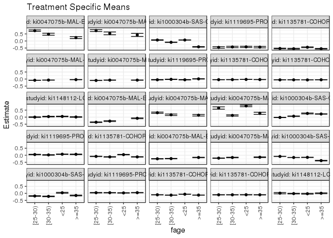

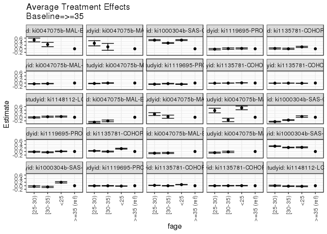

## Results Table

### Parameter: TSM

| agecat | studyid | country | intervention_level | baseline_level | estimate | ci_lower | ci_upper |
| --- | --- | --- | --- | --- | --- | --- | --- |
| 0-3 months | ki0047075b-MAL-ED | BANGLADESH | >=35 | NA | 0.2394988 | 0.1717633 | 0.3072344 |
| 0-3 months | ki0047075b-MAL-ED | BANGLADESH | [25-30) | NA | 0.7324133 | 0.6797485 | 0.7850782 |
| 0-3 months | ki0047075b-MAL-ED | BANGLADESH | [30-35) | NA | 0.4794463 | 0.4077799 | 0.5511127 |
| 0-3 months | ki0047075b-MAL-ED | NEPAL | >=35 | NA | 0.4298323 | 0.3200140 | 0.5396505 |
| 0-3 months | ki0047075b-MAL-ED | NEPAL | [25-30) | NA | 0.7390903 | 0.6712244 | 0.8069561 |
| 0-3 months | ki0047075b-MAL-ED | NEPAL | [30-35) | NA | 0.5388966 | 0.4381999 | 0.6395933 |
| 0-3 months | ki1000304b-SAS-CompFeed | INDIA | >=35 | NA | -0.4167617 | -0.4399039 | -0.3936195 |
| 0-3 months | ki1000304b-SAS-CompFeed | INDIA | <25 | NA | 0.0692853 | 0.0603381 | 0.0782326 |
| 0-3 months | ki1000304b-SAS-CompFeed | INDIA | [25-30) | NA | 0.0677549 | 0.0499048 | 0.0856049 |
| 0-3 months | ki1000304b-SAS-CompFeed | INDIA | [30-35) | NA | -0.0948399 | -0.1093173 | -0.0803626 |
| 0-3 months | ki1119695-PROBIT | BELARUS | >=35 | NA | -0.4366836 | -0.4886979 | -0.3846694 |
| 0-3 months | ki1119695-PROBIT | BELARUS | <25 | NA | -0.4182414 | -0.4590818 | -0.3774011 |
| 0-3 months | ki1119695-PROBIT | BELARUS | [25-30) | NA | -0.4581584 | -0.5136950 | -0.4026218 |
| 0-3 months | ki1119695-PROBIT | BELARUS | [30-35) | NA | -0.4253987 | -0.4725965 | -0.3782010 |
| 0-3 months | ki1135781-COHORTS | GUATEMALA | >=35 | NA | -0.5525427 | -0.5753524 | -0.5297330 |
| 0-3 months | ki1135781-COHORTS | GUATEMALA | <25 | NA | -0.4467575 | -0.4725275 | -0.4209876 |
| 0-3 months | ki1135781-COHORTS | GUATEMALA | [25-30) | NA | -0.5350340 | -0.5603486 | -0.5097193 |
| 0-3 months | ki1135781-COHORTS | GUATEMALA | [30-35) | NA | -0.5512714 | -0.5809892 | -0.5215536 |
| 3-6 months | ki0047075b-MAL-ED | BANGLADESH | >=35 | NA | -0.0815903 | -0.1105239 | -0.0526566 |
| 3-6 months | ki0047075b-MAL-ED | BANGLADESH | [25-30) | NA | -0.3608210 | -0.3840521 | -0.3375899 |
| 3-6 months | ki0047075b-MAL-ED | BANGLADESH | [30-35) | NA | -0.2835628 | -0.3159805 | -0.2511450 |
| 3-6 months | ki0047075b-MAL-ED | NEPAL | >=35 | NA | 0.1384430 | 0.0807607 | 0.1961254 |
| 3-6 months | ki0047075b-MAL-ED | NEPAL | [25-30) | NA | 0.3166615 | 0.2726149 | 0.3607082 |
| 3-6 months | ki0047075b-MAL-ED | NEPAL | [30-35) | NA | 0.1695185 | 0.1167521 | 0.2222849 |
| 3-6 months | ki0047075b-MAL-ED | PERU | >=35 | NA | 0.2734576 | 0.1983990 | 0.3485161 |
| 3-6 months | ki0047075b-MAL-ED | PERU | <25 | NA | 0.7984097 | 0.7412495 | 0.8555700 |
| 3-6 months | ki0047075b-MAL-ED | PERU | [25-30) | NA | 0.6509014 | 0.5689406 | 0.7328621 |
| 3-6 months | ki0047075b-MAL-ED | PERU | [30-35) | NA | 0.1229275 | 0.0780656 | 0.1677893 |
| 3-6 months | ki1000304b-SAS-CompFeed | INDIA | >=35 | NA | 0.2249590 | 0.2112642 | 0.2386538 |
| 3-6 months | ki1000304b-SAS-CompFeed | INDIA | <25 | NA | 0.2647046 | 0.2314152 | 0.2979940 |

[output cut: 62 more lines]

### Parameter: E(Y)

| agecat | studyid | country | intervention_level | baseline_level | estimate | ci_lower | ci_upper |
| --- | --- | --- | --- | --- | --- | --- | --- |
| 0-3 months | ki0047075b-MAL-ED | BANGLADESH | NA | NA | -0.0287949 | -0.0671002 | 0.0095105 |
| 0-3 months | ki0047075b-MAL-ED | NEPAL | NA | NA | 0.0411390 | -0.0145546 | 0.0968327 |
| 0-3 months | ki1000304b-SAS-CompFeed | INDIA | NA | NA | 0.0124966 | -0.0032603 | 0.0282535 |
| 0-3 months | ki1119695-PROBIT | BELARUS | NA | NA | -0.4374325 | -0.4965010 | -0.3783639 |
| 0-3 months | ki1135781-COHORTS | GUATEMALA | NA | NA | -0.5405498 | -0.5629687 | -0.5181310 |
| 3-6 months | ki0047075b-MAL-ED | BANGLADESH | NA | NA | -0.0311179 | -0.0605438 | -0.0016921 |
| 3-6 months | ki0047075b-MAL-ED | NEPAL | NA | NA | -0.0554236 | -0.1029996 | -0.0078477 |
| 3-6 months | ki0047075b-MAL-ED | PERU | NA | NA | 0.0351978 | -0.0209986 | 0.0913942 |
| 3-6 months | ki1000304b-SAS-CompFeed | INDIA | NA | NA | -0.0168853 | -0.0357401 | 0.0019694 |
| 3-6 months | ki1119695-PROBIT | BELARUS | NA | NA | 0.0473064 | 0.0279787 | 0.0666342 |
| 3-6 months | ki1135781-COHORTS | GUATEMALA | NA | NA | -0.0986159 | -0.1135079 | -0.0837240 |
| 6-12 months | ki0047075b-MAL-ED | BANGLADESH | NA | NA | -0.0860818 | -0.0985610 | -0.0736027 |
| 6-12 months | ki0047075b-MAL-ED | NEPAL | NA | NA | -0.0595839 | -0.0760822 | -0.0430856 |
| 6-12 months | ki1000304b-SAS-CompFeed | INDIA | NA | NA | -0.0858013 | -0.0900320 | -0.0815706 |
| 6-12 months | ki1000304b-SAS-FoodSuppl | INDIA | NA | NA | -0.1080113 | -0.1390238 | -0.0769988 |
| 6-12 months | ki1119695-PROBIT | BELARUS | NA | NA | 0.0416292 | 0.0251876 | 0.0580707 |
| 6-12 months | ki1135781-COHORTS | GUATEMALA | NA | NA | -0.1091839 | -0.1163423 | -0.1020255 |
| 6-12 months | ki1135781-COHORTS | PHILIPPINES | NA | NA | -0.0999580 | -0.1051268 | -0.0947892 |
| 6-12 months | ki1148112-LCNI-5 | MALAWI | NA | NA | -0.0054695 | -0.0426418 | 0.0317029 |
| 12-24 months | ki0047075b-MAL-ED | BANGLADESH | NA | NA | -0.0162473 | -0.0222513 | -0.0102433 |
| 12-24 months | ki0047075b-MAL-ED | NEPAL | NA | NA | -0.0298967 | -0.0377257 | -0.0220676 |
| 12-24 months | ki1119695-PROBIT | BELARUS | NA | NA | -0.0429788 | -0.0603736 | -0.0255841 |
| 12-24 months | ki1135781-COHORTS | GUATEMALA | NA | NA | -0.0294369 | -0.0331367 | -0.0257372 |
| 12-24 months | ki1135781-COHORTS | PHILIPPINES | NA | NA | -0.0579786 | -0.0605237 | -0.0554336 |
| 12-24 months | ki1148112-LCNI-5 | MALAWI | NA | NA | -0.0199381 | -0.0356954 | -0.0041807 |

### Parameter: ATE

| agecat | studyid | country | intervention_level | baseline_level | estimate | ci_lower | ci_upper |
| --- | --- | --- | --- | --- | --- | --- | --- |
| 0-3 months | ki0047075b-MAL-ED | BANGLADESH | >=35 | >=35 | 0.0000000 | 0.0000000 | 0.0000000 |
| 0-3 months | ki0047075b-MAL-ED | BANGLADESH | [25-30) | >=35 | 0.4929145 | 0.3869923 | 0.5988368 |
| 0-3 months | ki0047075b-MAL-ED | BANGLADESH | [30-35) | >=35 | 0.2399475 | 0.1171974 | 0.3626976 |
| 0-3 months | ki0047075b-MAL-ED | NEPAL | >=35 | >=35 | 0.0000000 | 0.0000000 | 0.0000000 |
| 0-3 months | ki0047075b-MAL-ED | NEPAL | [25-30) | >=35 | 0.3092580 | 0.1629615 | 0.4555545 |
| 0-3 months | ki0047075b-MAL-ED | NEPAL | [30-35) | >=35 | 0.1090643 | -0.0829938 | 0.3011225 |
| 0-3 months | ki1000304b-SAS-CompFeed | INDIA | >=35 | >=35 | 0.0000000 | 0.0000000 | 0.0000000 |
| 0-3 months | ki1000304b-SAS-CompFeed | INDIA | <25 | >=35 | 0.4860471 | 0.4611070 | 0.5109871 |
| 0-3 months | ki1000304b-SAS-CompFeed | INDIA | [25-30) | >=35 | 0.4845166 | 0.4579903 | 0.5110429 |
| 0-3 months | ki1000304b-SAS-CompFeed | INDIA | [30-35) | >=35 | 0.3219218 | 0.3021499 | 0.3416937 |
| 0-3 months | ki1119695-PROBIT | BELARUS | >=35 | >=35 | 0.0000000 | 0.0000000 | 0.0000000 |
| 0-3 months | ki1119695-PROBIT | BELARUS | <25 | >=35 | 0.0184422 | -0.0130014 | 0.0498859 |
| 0-3 months | ki1119695-PROBIT | BELARUS | [25-30) | >=35 | -0.0214748 | -0.0590628 | 0.0161133 |
| 0-3 months | ki1119695-PROBIT | BELARUS | [30-35) | >=35 | 0.0112849 | -0.0268119 | 0.0493817 |
| 0-3 months | ki1135781-COHORTS | GUATEMALA | >=35 | >=35 | 0.0000000 | 0.0000000 | 0.0000000 |
| 0-3 months | ki1135781-COHORTS | GUATEMALA | <25 | >=35 | 0.1057851 | 0.0729062 | 0.1386641 |
| 0-3 months | ki1135781-COHORTS | GUATEMALA | [25-30) | >=35 | 0.0175087 | -0.0148978 | 0.0499153 |
| 0-3 months | ki1135781-COHORTS | GUATEMALA | [30-35) | >=35 | 0.0012713 | -0.0345814 | 0.0371239 |
| 3-6 months | ki0047075b-MAL-ED | BANGLADESH | >=35 | >=35 | 0.0000000 | 0.0000000 | 0.0000000 |
| 3-6 months | ki0047075b-MAL-ED | BANGLADESH | [25-30) | >=35 | -0.2792308 | -0.3202477 | -0.2382138 |
| 3-6 months | ki0047075b-MAL-ED | BANGLADESH | [30-35) | >=35 | -0.2019725 | -0.2484420 | -0.1555030 |
| 3-6 months | ki0047075b-MAL-ED | NEPAL | >=35 | >=35 | 0.0000000 | 0.0000000 | 0.0000000 |
| 3-6 months | ki0047075b-MAL-ED | NEPAL | [25-30) | >=35 | 0.1782185 | 0.0978966 | 0.2585404 |
| 3-6 months | ki0047075b-MAL-ED | NEPAL | [30-35) | >=35 | 0.0310754 | -0.0573375 | 0.1194884 |
| 3-6 months | ki0047075b-MAL-ED | PERU | >=35 | >=35 | 0.0000000 | 0.0000000 | 0.0000000 |
| 3-6 months | ki0047075b-MAL-ED | PERU | <25 | >=35 | 0.5249522 | 0.4199033 | 0.6300011 |
| 3-6 months | ki0047075b-MAL-ED | PERU | [25-30) | >=35 | 0.3774438 | 0.2479125 | 0.5069752 |
| 3-6 months | ki0047075b-MAL-ED | PERU | [30-35) | >=35 | -0.1505301 | -0.2469094 | -0.0541508 |
| 3-6 months | ki1000304b-SAS-CompFeed | INDIA | >=35 | >=35 | 0.0000000 | 0.0000000 | 0.0000000 |
| 3-6 months | ki1000304b-SAS-CompFeed | INDIA | <25 | >=35 | 0.0397456 | -0.0023436 | 0.0818348 |

[output cut: 62 more lines]